# Data Dudes Project

Last compiled on 13 December, 2022

#### 0.0.0.1 **TEAM NAME: Data Dudes**

| Last Name (Family) | First Name (Given) | Student ID |
| --- | --- | --- |
| Azam | Faiza | 169020565 |
| Beatty | Jamie | 169027003 |
| Doneva | Anna | 169042350 |
| **Hassan** | Yusra | 169024293 |
| Khan | Samiyah | 169024449 |
| Patel | Janaki | 169037500 |

# 1 Introduction

Our job was to analyze how the climate situation relates to various factors along with how those factors relate within themselves. The datasets we worked with to assess this are Sea Ice Rate Of Change, INT Emissions, Climate change opinion survey 2021, Primary Energy and Biofuel. After tidying these data sets and creating an individual analysis for each, we learned about trends for each of them. We also answered a variety of questions through creating multiple joint analyses by combining different data sets. This, along with comparing our findings with an article, allowed us to create our conclusion.

**Climate Change opinion survey 2021**

Currently this dataset is made up of 18 different datasets. It lists countries’ answers to different questions like how do you feel about participating in climate action. Each has the first column stating possible answers to a question asked relating to climate change -this is categorical, while the rest of the columns are countries containing how many people from each answered each option -these are integers. Once tidied, it becomes one dataset with the first column as countries (categorical) and the rest as answers to questions with the valurs being how many people from each country answered each answer (integer). To differentiate the answers by what question was asked, the topic is made part of the column name with a dash between its answer. The tidied data has 31 rows and 109 columns. There are a few columns that include many NAs -these are the ideology topic questions and the party question. It happens because the ideology_us and party questions were asked to only the US and ideology_row was asked to every country but the US. The data can not be joined however, because there is a different amount of responses.

**INT Emissions**

The export emissions data set contains data on the amount of emissions countries have produced from years 1949-2019. The emissions are split into four different emission types; Total C02 emissions (MMtonnes), Coal and Coke (MMtonnes C02), Consumed Natural gas (MMtonnes C02), Petroleum and other liquids (MMtonnes C02). There is only data for the USA and World from the years 1949-1980, so I solely used the data for years after 1980. The data set contains 4 variables: API, type: character; Emissions(formerly untitled), type: while importing, set to double; Year, type: originally character, changed while tidying to int; Amount, type: while importing, set to double. Emissions contains the name of the emissions types, Year goes from 1949-2019, but for most of the data set from 1980-2019. Amount is the quantity of CO2 emissions for each emission type in MMtonnes per year.

**Sea Ice Rate of Change**

This data set hold data of the sea ice index rates of change for different years and each month. The sea ice index rate of change data set gives us the rates for every year from 1978 to 2022 through January to December, containing 46 observations and 13 variables. Under each month the variable type is set to double as it contains the rate of change index. The year variable type was set to integer after that dataset was tidied up.

**Biofuel** There are 5 variables, and 42256 observations worth of data. The variables consist of: API (chr), Type (chr), Years (int), Amount (dbl), Country (chr).

**Primary Energy**

# 2 Tidying

We started off by loading and importing all our data in and tidying it one by one.

**Climate Change opinion survey 2021** The climate survey datasets were cleaned by creating a tidying function, applying it to each individual dataset and joining them using the reduce function.

**INT Emissions** The emissions dataset was cleaned by: 1. Combining years and renaming Emissions: Using the rename and the pivot_longer functions, I converted the year columns into one column and added the values into their own column as well. 2. Turning years into int: Using the as.integer() function to change its type. 3. Deleting emissions title rows: Using filter() to separate only the Emissions rows that don’t equal Emissions. 4. Deleting rows from 1949-1978: Using filter() to separate only the years after 1980. 5. Making a country column: Using mutate I created a new column called Country by separating the rows that have an N/A value under the API column.

**Sea Ice Rate of Change** The Sea Ice Index was tidied by renaming the first column to year, converting its type to int and removing the problematic entry “1981-2010” which couldn’t be converted.

**Biofuel** The first step cleaning up this data was my importing using the read_csv function, as the Biofuel data set was contained in a csv file. Next, the years 1980 to 2019 each had their own columns, making the data set unnecessarily long (42 variables total). The first step was using the “pivot_longer()” function to create one column called “Years”, which represented the entirety of the 39 year period, arranged in ascending order. Then, I saved these changed into a new variable called “Transformed”, as this would act as my “data set” when I continued to tidy data. Here I also made sure that the Years variable type was “int”, and the Amount variable type was “dbl”. The last part of tidying data was renaming the column that contains information about biofuel presence, production and consumption to “Type”, creating a new column for countries as the countries and the information in the now “Type” variable were in the same column. To efficiently separate the countries from the rest of the biofuel data, I used an ifelse(…) statement so that if it recognizes that country as its API, it get’s put into the newly mutated “Countries” column, if not, then that information goes into the “Type” column.

**Primary Energy** The Primary Energy dataset was imported using read_csv. We made a separate year, amount, energy, country column and changed some variable types.

# 3 Individual Analysis

## 3.1 Climate Survey Data

Instead of trying to tackle every variable, I decided to choose a few that would best represent a country’s concern for climate change and used these in my analysis later on. The first thing I did was try and find the country that had the highest percentage of responses for each category. For three of them, this turned out to be Costa Rica. I decided to take this further and see if its region (South/Latin America) seemed to have higher worry in general.

This plot measuring worry by region, seemed to support that theory:

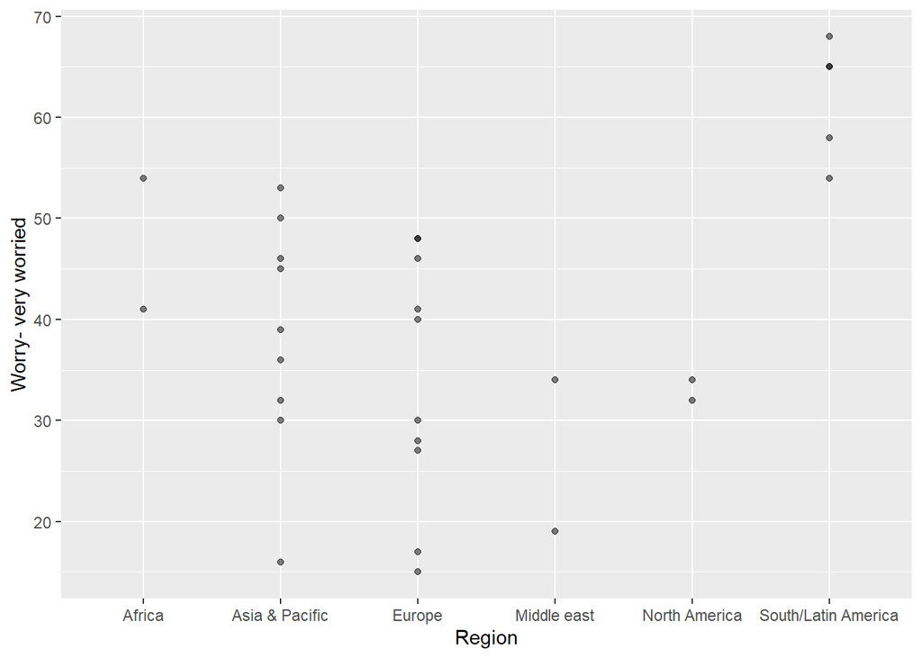

Next, I tried to find relationships within my chosen variables. I did so by examining their graphs and looking at the correlations.

```
## [1] 0.3048783 0.5496514 0.5539162 0.6021155
```

```
## # A tibble: 1 × 12
##   r.squ…¹ adj.r…² sigma stati…³ p.value    df logLik   AIC   BIC devia…⁴ df.re…⁵
##     <dbl>   <dbl> <dbl>   <dbl>   <dbl> <dbl>  <dbl> <dbl> <dbl>   <dbl>   <int>
## 1   0.363   0.340  10.6    15.9 4.31e-4     1  -112.  231.  235.   3141.      28
## # … with 1 more variable: nobs <int>, and abbreviated variable names
## #   ¹r.squared, ²adj.r.squared, ³statistic, ⁴deviance, ⁵df.residual
```

## 3.2 Emissions

In the Emissions dataset, we focused in on Canada, United States and the World.

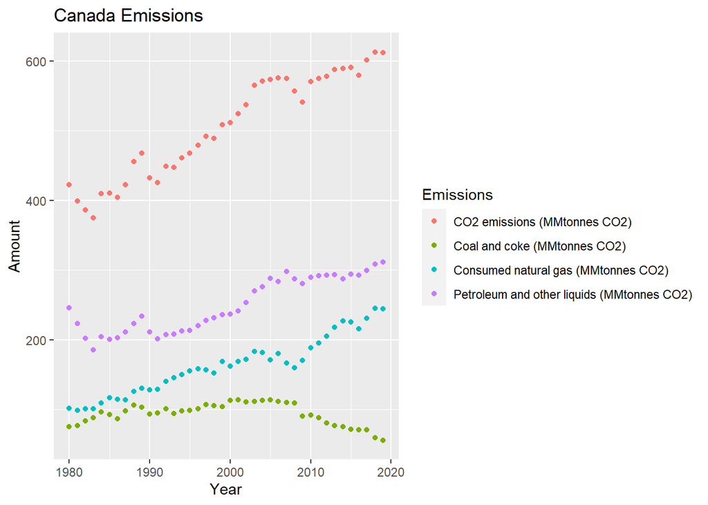

Canada’s emissions: This is a graph plotting Canada’s emissions from years 1980 to 2019. All four emission types are represented in the graph, C02 emissions being an accumulation of the other three. Petroleum and other liquids have had the most C02 emissions of the 3 types, and its emissions have risen slightly the past 40 years, with some drops in the early 80s but pretty steady increase thereafter. Coal and coke emissions have remained around the same, with a decrease after 2010. Consumed natural gas has had a similar rise in emissions to Petroleum, with a slight decrease around 2005. Total C02 emissions have had the most dramatic rise, with fluctuations happening during the early 80s, early 90s, and late 2000s.

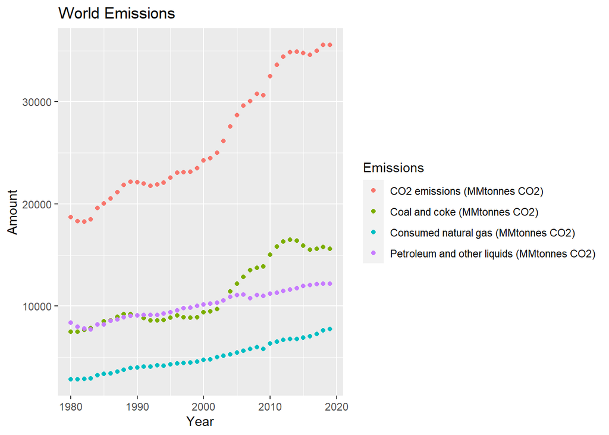

World emissions: This graph plots the world’s emissions from the years 1980 to 2019. Consumed natural gas has had a steady increase in emissions, and so has Petroleum and other liquids. Coal and coke have had the most fluctuations in emission levels, increasing dramatically after 2000. This is unlike Canada who has had coal and coke emissions decline in recent years. The overall C02 emissions have increased greatly the past 40 years, with occasional decreases throughout.

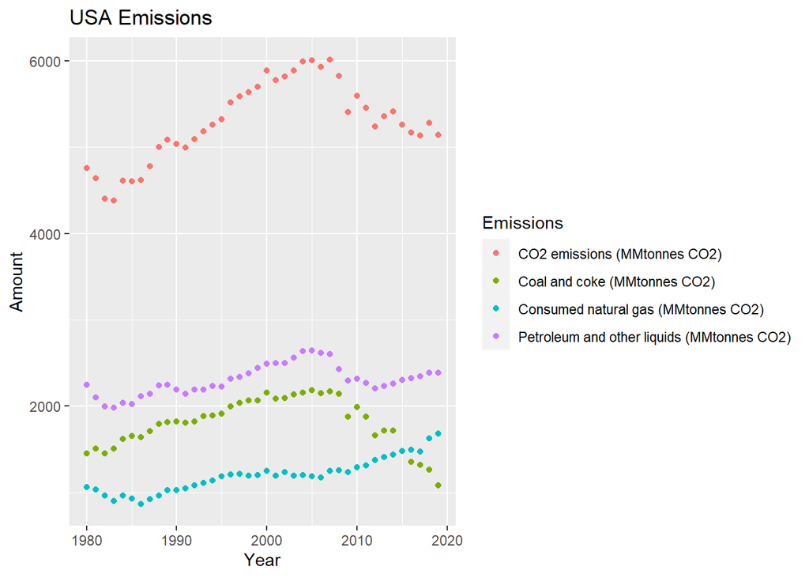

USA emissions: This graph plots the USA’s emissions from years 1980 to 2019. Unlike the world and Canada, C02 emissions have declined after 2005. Consumed natural gas use has increased steadily, and Petroleum decreased after 2005, but started increasing again after 2012. Coal and coke emissions have had a dramatic decrease after 2005. World model for C02 emissions: The model for world C02 emissions is y= 488.8x -951154.8. The multiple R squared is close to 1, the model capturing 94.52% of the data, meaning it is a good model.

Model for World Coal and Coke emissions: The model for world coal and coke emissions is y=251.08x -490865.04. The multiple R squared is close to 1, to model capturing 85.53% of the data, making it a good representation of the data.

World model for Natural gas emissions: The model for world natural gas emissions is y = 1.216e+02x -2.383e+05. The multiple R squared is close to 1, the model capturing 97.91% of the data, making it a good model.

World model for Petroleum and other liquids: The model for world petroleum and other liquids emissions is y = 1.161e+02x -2.220e+05. The model is a good representation of the data because the multiple R squared is close to 1, the model capturing 98.30% of the data.

Overall, in my individual analysis I compared the amount of emissions the world, Canada, and the USA have produced in the past 40 years. Other than in the USA, total C02 emissions have increased steadily, seeing the most dramatic increase in world emissions. For most of the 40 year period, consumed natural gas emissions have been the lowest of the three types for the world and USA. For Canada the lowest was coal and coke emissions, with both Canada and the USA seeing this emission steadily decline in recent years. In conclusion, there is a positive linear correlation between the year and C02 emissions for the past 40 years.

## 3.3 Ice_Roc

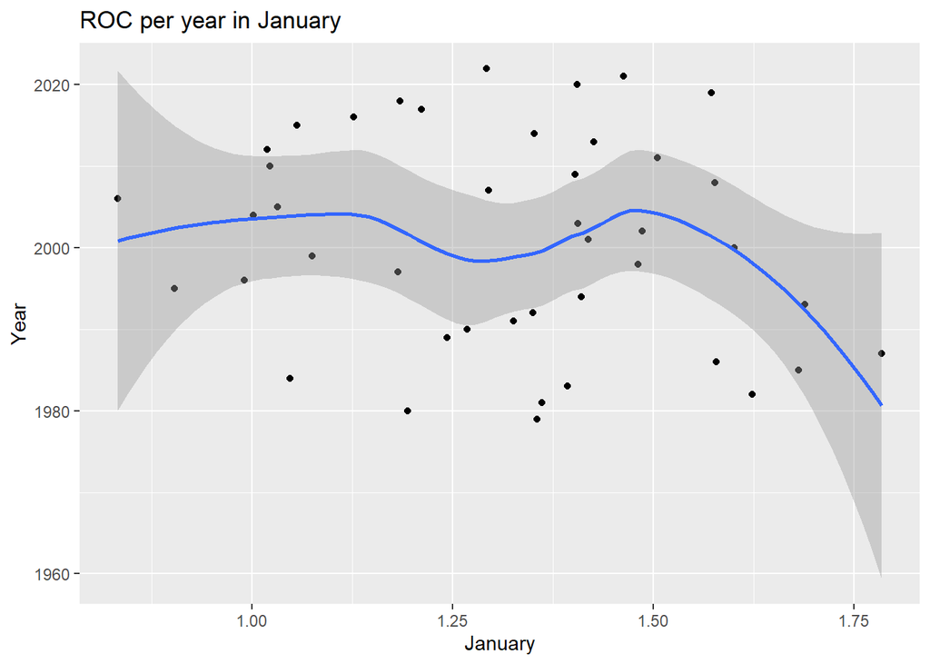

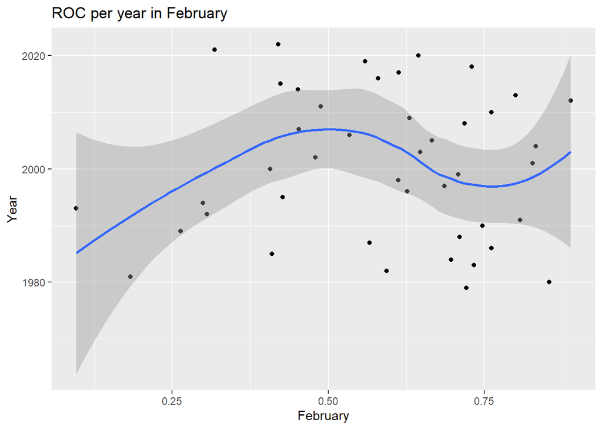

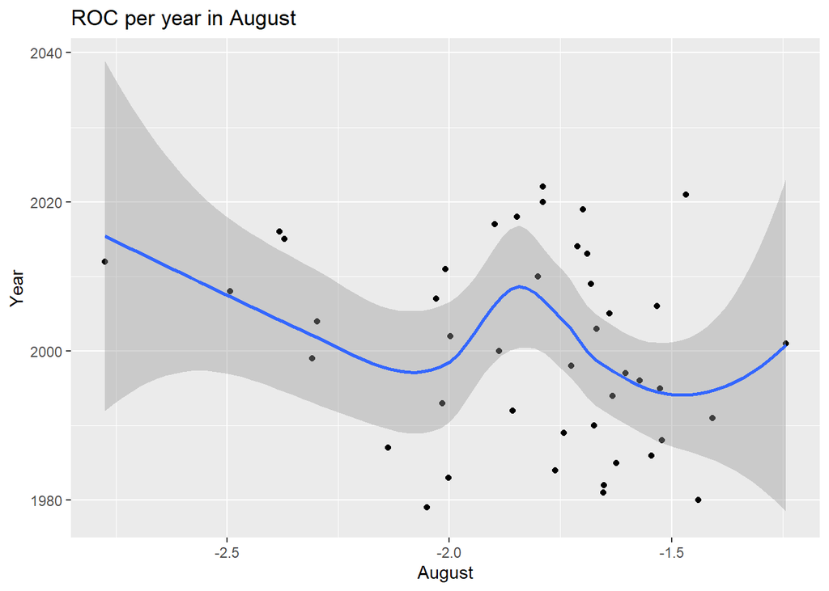

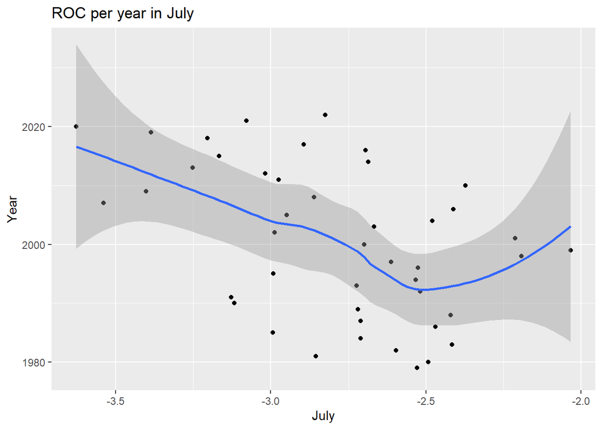

## 3.4 Biofuel

In this particular analysis, it was best to use a bar graph that displays the consumption and production of a particular amount of Ethanol Fuel and Biomass Based Diesel. The countries United States, Brazil, and Zimbabwe were chosen to work with. These three countries are based on their levels of development (their standing in industrialization). For instance, the United States is ranked higher economically and in terms of the resources they have available for their country’s sustainability. Brazil is considered up and coming following the United States, which leaves Zimbabwe. It was important to compare their developments as countries as that would help us see which countries are able to use renewable, efficient energy sources based on their means to continue as nations.

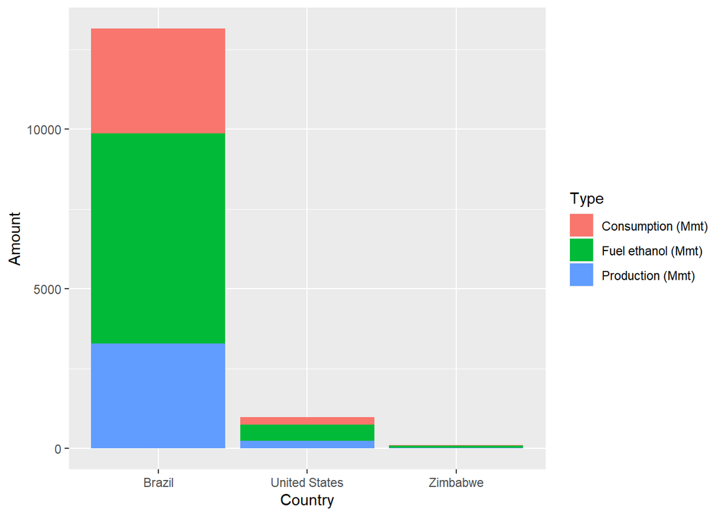

Looking at the first graph, this is based on the year 1981, where Brazil had a moderately high level of Ethanol Fuel, consumption and production of Ethanol Fuel. United States in comparison had significantly lower levels of Ethanol Fuel available, consumption and production levels. Lastly, Zimbabwe does not produce or consume this fuel, but they have an insignificant amount of Ethanol Fuel accessible.

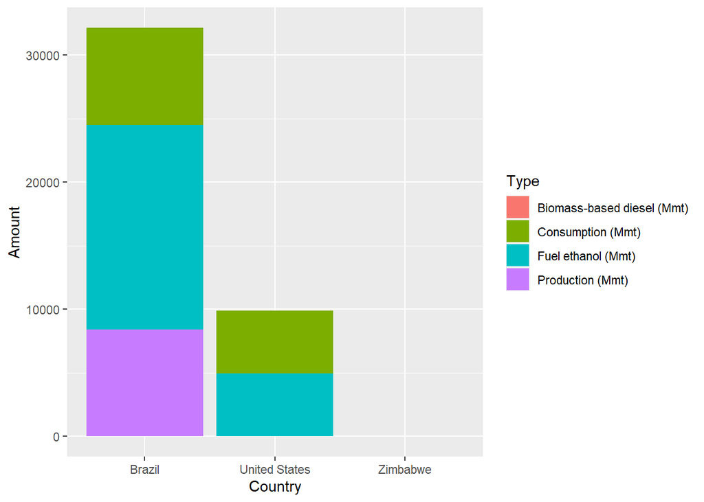

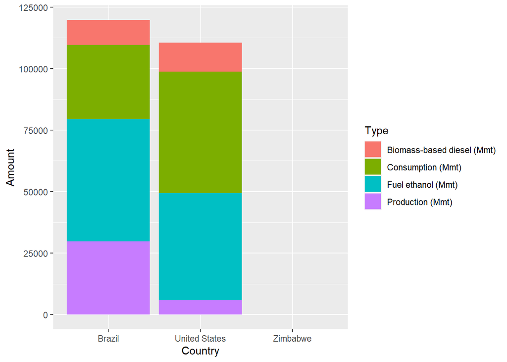

Whether the biofuel being used is Ethanol or Biomass Based Based Diesel, acquiring of new knowledge regarding renewable and sustainable fuels also comes the understanding of what force is needed in order to finance these new methods. Zimbabwe showed no crucial improvements towards the availability, let alone the production and consumption of biofuels. Understanding the state of their economy, we can draw conclusions as to why there has been no progression in the duration of the 38 years worth of statistics shown in three different periods. If research continues, we will be able to increase the use and availability of biofuels five times more than it was in 2019.

## 3.5 Primary Energy

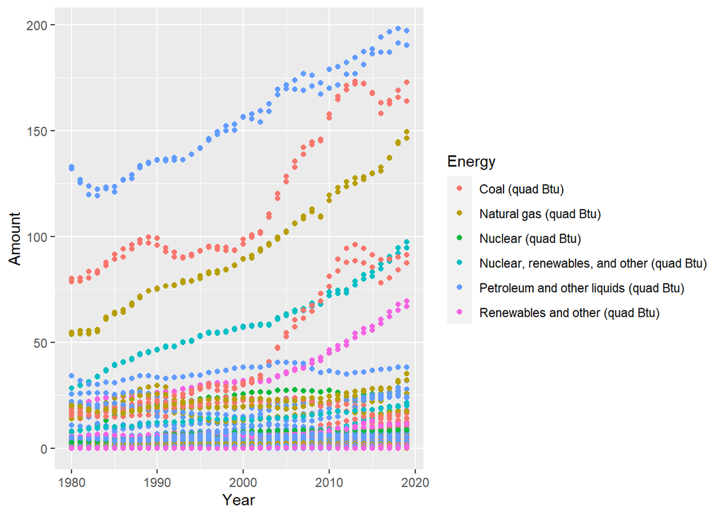

As the amount of energy sources used, such as coal, oil, and natural gas, increases over time, we can observe a positive association in the graph. The energies have a positive correlation showing a greater usage of different energies closer to recent years. All of the energies are gradually rising as well, some more later than others. such as renewable energy, which primarily began to do so in 2010. In accordance with growing environmental concerns, natural gas usage is rising more quickly and consistently than those of any other energy source.

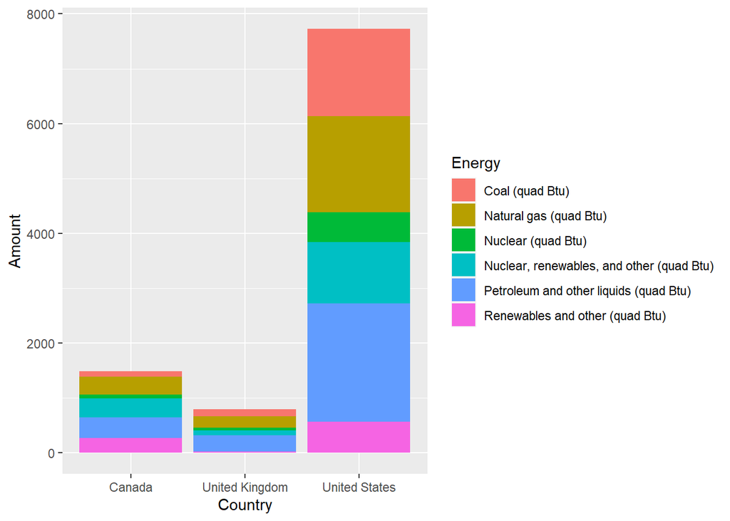

The graph shows the energies broken down by nation. The height of the bar represents the total amount of energy used by the nation, while the various colours represent the quantity of each energy. We can observe that the primary energy used in the United States is substantially higher. with fossil fuels like coal and petroleum making up the bulk. Even though they use primary energy at a far lower rate, the other nations still rely heavily on petroleum and other fossil fuels.

# 4 Joint Analysis

After finishing our individual findings, we wanted to put them together to hopefully draw further conclusions and connections from the data. We came up with a few questions to guide our research:

## 4.1 Do countries with primary energy as coal have higher emissions?

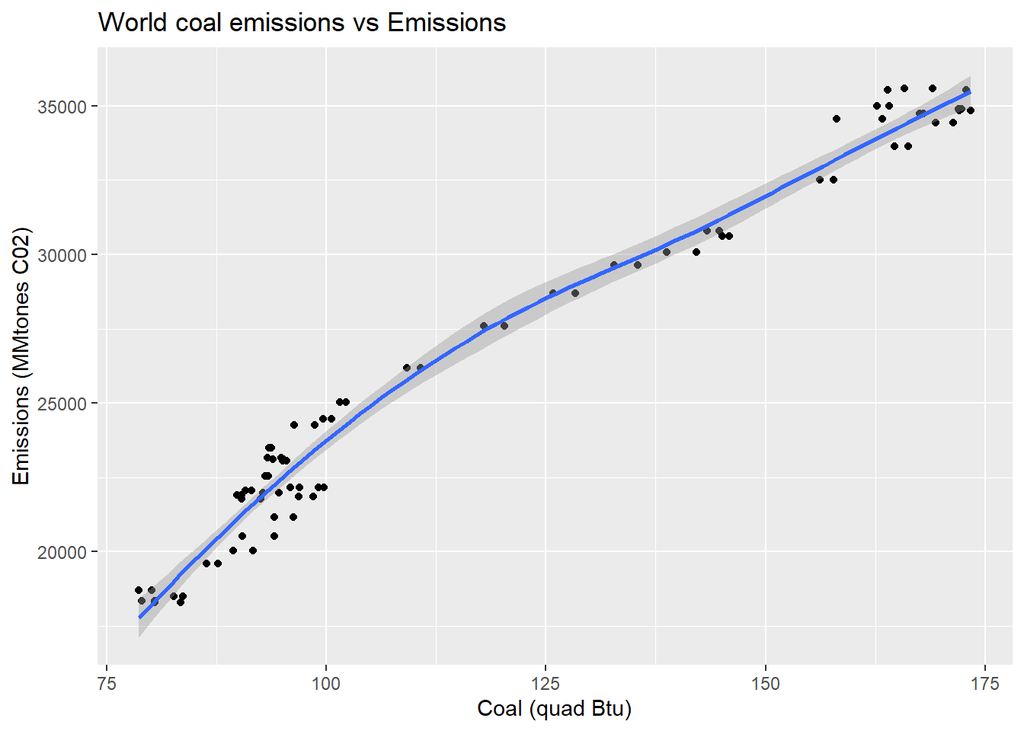

```r
countries_chosen <- c("Canada", "United States", "United Kingdom", "Australia", "China", "World")

w_emissions <- t_emissions %>%
  filter(Country %in% countries_chosen, Emissions == "CO2 emissions (MMtonnes CO2)")
w_primary_energy <- t_primary_energy %>%
  filter(Country %in% countries_chosen, Energy == "Coal (quad Btu)")
joined_data <- inner_join(w_primary_energy, w_emissions, by = c("Year", "Country"))
#view(joined_data)

joined_data %>%
  filter(Country == "World") %>%
  ggplot(aes(Amount.x, Amount.y)) + geom_point() + geom_smooth() +
  labs(title = "World coal emissions vs Emissions", x = "Coal (quad Btu)", y = "Emissions (MMtones C02)")
```

```r
cor(joined_data$Amount.x, joined_data$Amount.y)
```

```
## [1] 0.9709438
```

Comparing China and the United States

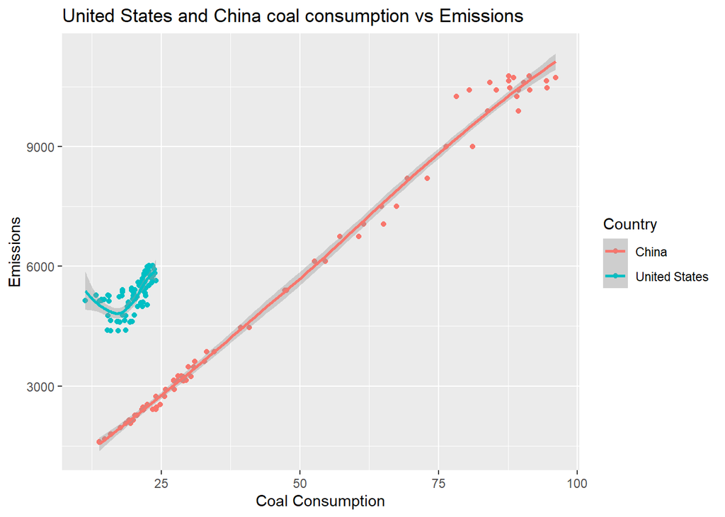

```r
joined_data %>%
  filter(Country == "United States" | Country == "China") %>%
  ggplot(aes(Amount.x, Amount.y, colour = Country)) + geom_point() + geom_smooth() +
  labs(title = "United States and China coal consumption vs Emissions", x = "Coal Consumption", y = "Emissions")
```

This graph shows the sheer amount of coal China is using, and how much greater it is from the United States. There is a very strong positive linear correlation between coal consumption and the amount of C02 emissions a country has, being especially prevalent for China.

Graphing remaining countries

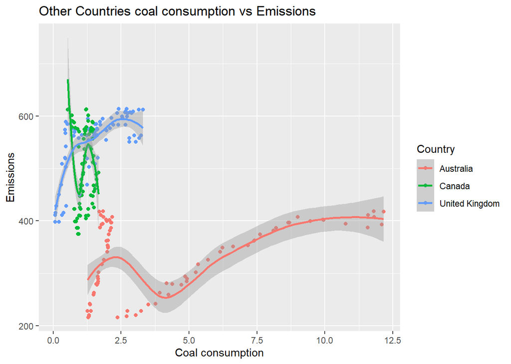

```r
joined_data %>%
  filter(!Country %in% c("United States", "China", "World")) %>%
  ggplot(aes(Amount.x, Amount.y, colour = Country)) + geom_point() + geom_smooth() +
  labs(title = "Other Countries coal consumption vs Emissions", x = "Coal consumption", y = "Emissions")
```

The results for the remaining three countries is a lot more varied. Especially when there is a low coal consumption, the overall C02 emissions fluctuate greatly. This is probably due to the multiple other factors affecting emissions, and when a country doesn’t rely as heavily on coal, it is still relying on other energy sources contributing to their overall emissions.

## 4.2 Do countries with higher climate concern have similar primary energies?

Similar primary energies are found in nations with greater climate concern. Ecosystems, human health, and the economy are all being negatively impacted by the changing global climate. South and Latin America’s countries utilise a lot more fossil fuels than alternative energy sources, including biofuels, waste, oil, and coal. Countries like Argentina consumed more than 1 million barrels of oil as energy and Brazil consumed over 4 million. Although the countries vary in amount due to population they use a lot less than countries such as China or the United States, yet these countries also have the highest levels of climate concern, with over 50 individuals in each study concerned about the environment.

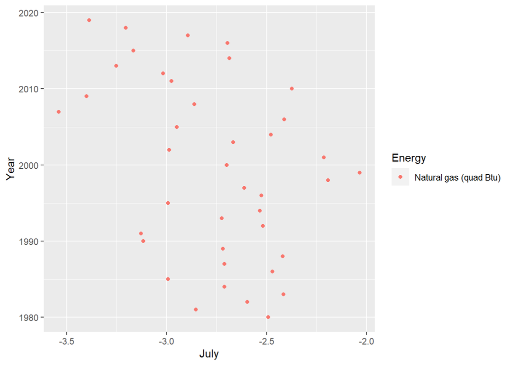

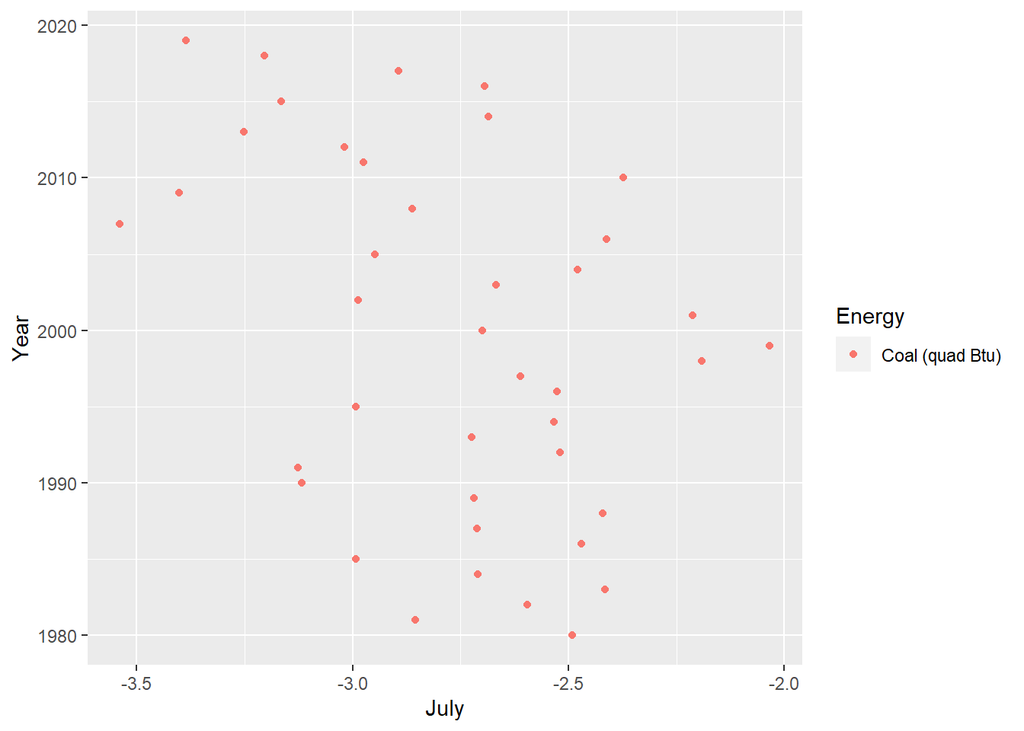

## 4.4 Does increased biofuel usage help lower emissions?

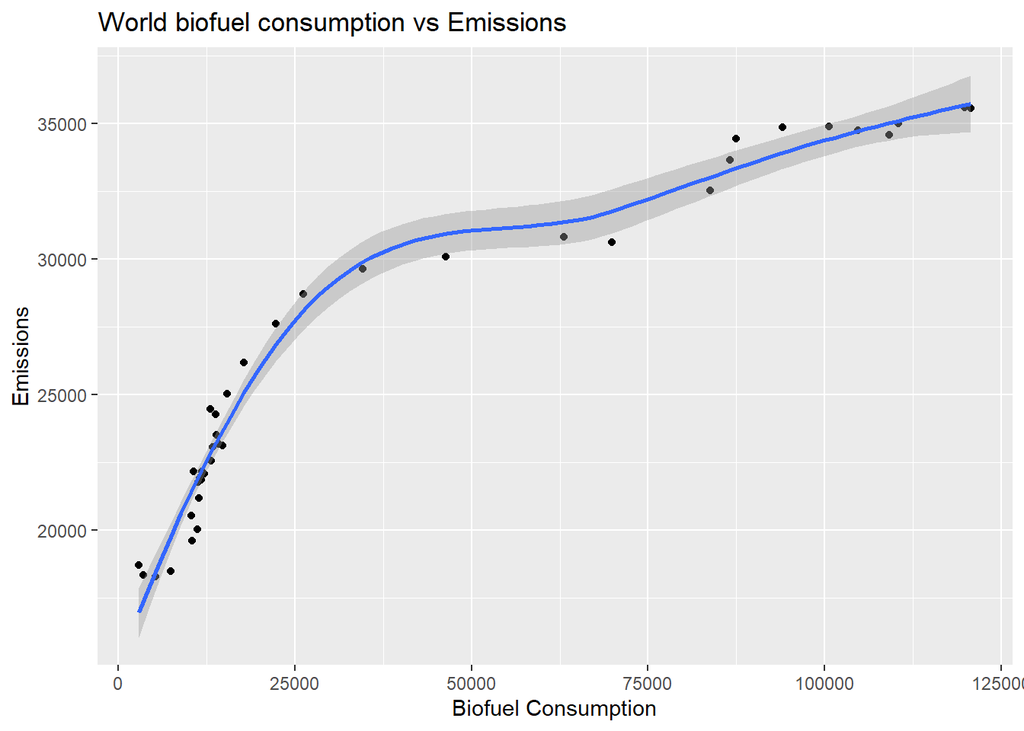

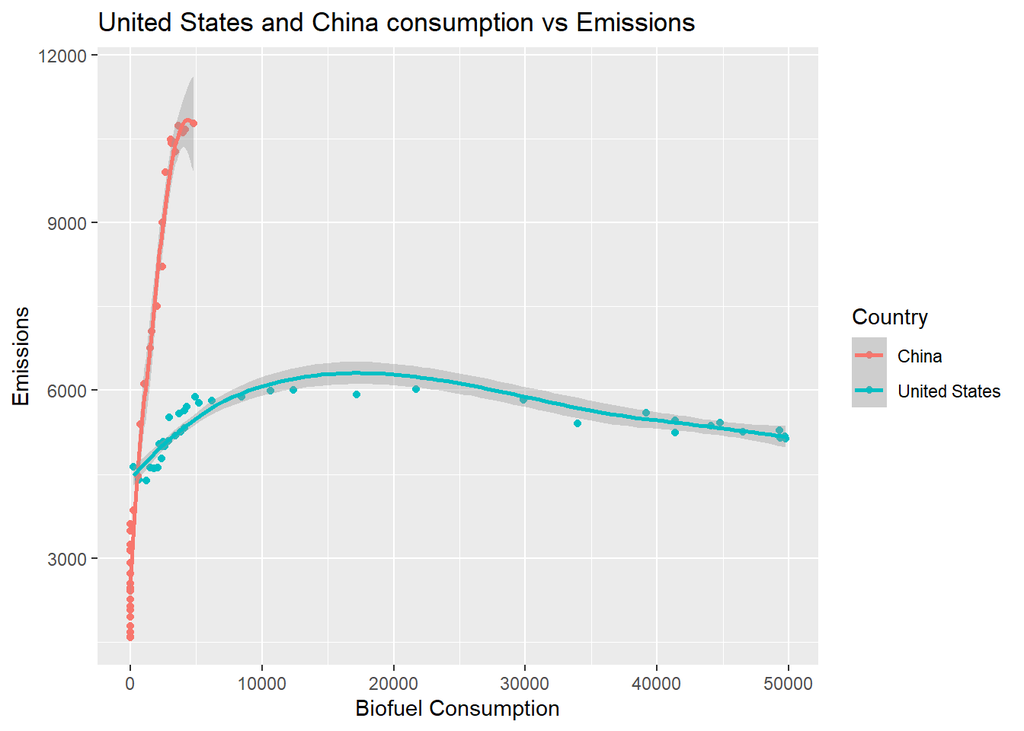

## 4.5 Does South/Latin America have lower emissions since they seem to be the most concerned?

The following graph shows emissions by region. We see that South America does have some of the lowest emissions.

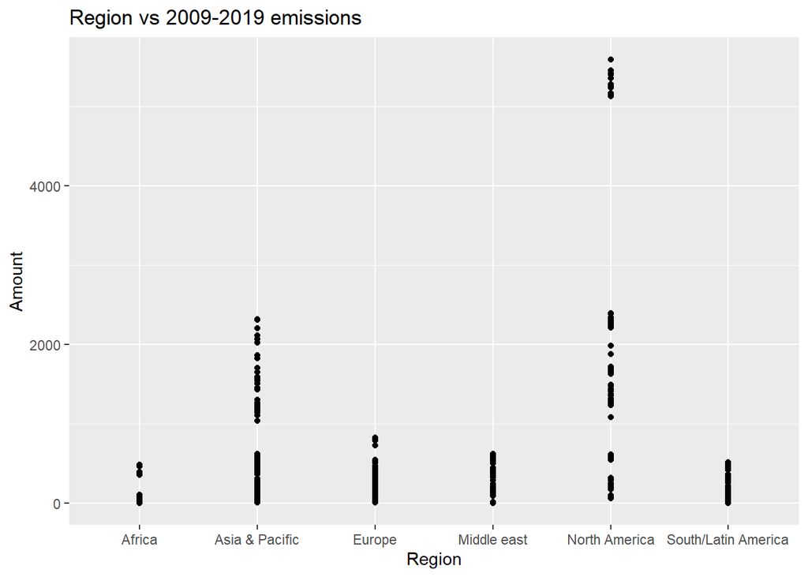

However, it’s important to make sure that these results follow through for other countries as well. To do this, I decided to plot worry by emissions and check the correlation of these two variables.

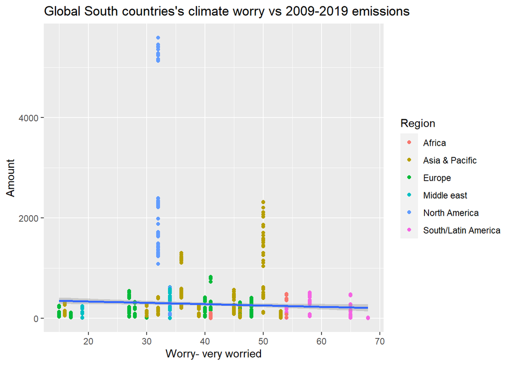

```
## [1] -0.06474658
```

Both the graph’s line of best fit and the correlation show that the relationship isn’t very strong. That means, even if it holds true for Costa Rica and the South America region, it is not a good idea to try to use a country’s worry to predict its emissions. In hindsight, this makes sense because it could be possible for a country to be really worried even if they have high emissions because bringing them down may be really difficult.

Citation: “Climate Change Background Info.” Clean Foundation, 21 July 2020, https://cleanfoundation.ca/climate-change-background-info/?gclid=Cj0KCQiAnNacBhDvARIsABnDa6-TuAqIyb8xP7KAOGZahfTiloMVwDc3fq5tVT4qm_-kAD9iZw0daQkaArKEEALw_wcB. Accessed 08 December 2022.

# 5 Conclusions

In conclusion, there are significant regional differences in both climate concerns and emissions. Some nations, including those in the European Union, have drastically cut their emissions of greenhouse gases while increasing their usage of renewable energy sources. However, some nations continue to heavily rely on fossil fuels, particularly those with economies that are expanding quickly, which has led to a rise in their emissions. As a renewable energy source, the usage of biofuels varies greatly amongst nations as well. While some have made substantial efforts to include them in their energy mix, others have been slower to do so. In order to combat climate change, there must be a worldwide effort and a determined effort on the part of all nations to switch to greener kinds of energy.